# P1_Test a Perceptual Phenomenon

## Project 1: Test a Perceptual Phenomenon

### Background Information:

In a Stroop task, participants are presented with a list of words, with each word displayed in a color of ink. The participant’s task is to say out loud the color of the ink in which the word is printed. The task has two conditions: a congruent words condition, and an incongruent words condition. In the congruent words condition, the words being displayed are color words whose names match the colors in which they are printed: for example RED, BLUE. In the incongruent words condition, the words displayed are color words whose names do not match the colors in which they are printed: for example PURPLE, ORANGE. In each case, we measure the time it takes to name the ink colors in equally-sized lists. Each participant will go through and record a time from each condition.

### Questions For Investigation

As a general note, be sure to keep a record of any resources that you use or refer to in the creation of your project. You will need to report your sources as part of the project submission.

### Question 1

What is our independent variable? What is our dependent variable?

**A1:** *Independent variables are Congruent Word Conditions and InCongruent Word Conditions; Dependent Variable is The time it takes to name in equally-sized lists from each condition.*

### Question 2

What is an appropriate set of hypotheses for this task? What kind of statistical test do you expect to perform? Justify your choices.

**A2:** *The null hypothesis is the time to name the ink colors in Congruent Word Conditions and the time to name the ink colors in InCongruent Word Conditions ARE EQUAL. The alternative hypothesis is the time to name the ink colors in Congruent Word Conditions and the time to name the ink colors in InCongruent Word Conditions ARE NOT EQUAL (either can be faster/slower).*  
*The type of statistical test is Dependent t-test, with repeated measures design. We are having the same group of participants read two sets of words (two conditions applied to same sample participants).*

\begin{equation*} H_{0}: \mu_{1} = \mu_{2} \text{where } \\\\ H_{a}: \mu_{1} \neq \mu_{2} \\\\ \text{where } H_{0} \text{ is the null hypothesis; } \\\\ \text{and } H_{a} \text{ is the alternative hypothesis; } \\\\ \text{and } \mu_{1} \text{ is the mean of congruent data set; } \\\\ \text{and } \mu_{2} \text{ is the mean of incongruent data set; } \\\\ \end{equation*}

### Question 3

Report some descriptive statistics regarding this dataset. Include at least one measure of central tendency and at least one measure of variability.

```python
# import all necessary packages and functions.
import csv
from datetime import datetime
import numpy as np
import pandas as pd
from IPython.display import display
import matplotlib.pyplot as plt
import scipy.stats as stats
import seaborn as sns
%matplotlib inline
```

```python
stroop_data = pd.read_csv('stroopdata.csv')
display(stroop_data.head())
stroop_data.describe()
```

|  | Congruent | Incongruent |
| --- | --- | --- |
| 0 | 12.079 | 19.278 |
| 1 | 16.791 | 18.741 |
| 2 | 9.564 | 21.214 |
| 3 | 8.630 | 15.687 |
| 4 | 14.669 | 22.803 |

|  | Congruent | Incongruent |
| --- | --- | --- |
| count | 24.000000 | 24.000000 |
| mean | 14.051125 | 22.015917 |
| std | 3.559358 | 4.797057 |
| min | 8.630000 | 15.687000 |
| 25% | 11.895250 | 18.716750 |
| 50% | 14.356500 | 21.017500 |
| 75% | 16.200750 | 24.051500 |
| max | 22.328000 | 35.255000 |

**A3:** *Descriptive Stats were determined programmatically using Pandas, as shown above.*

### Question 4

Provide one or two visualizations that show the distribution of the sample data. Write one or two sentences noting what you observe about the plot or plots.

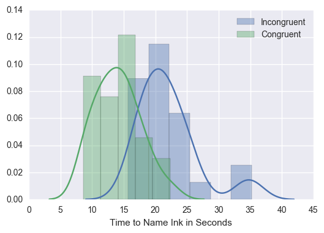

```python
congruent_data = stroop_data.Congruent
incongruent_data = stroop_data.Incongruent
# print(congruent_data.head())
# print(incongruent_data.head())

# congruent_fit = stats.norm.pdf(congruent_data, np.mean(congruent_data), np.std(congruent_data))
# incongruent_fit = stats.norm.pdf(incongruent_data, np.mean(incongruent_data), np.std(incongruent_data))


sns.distplot(incongruent_data, hist=True, label="Incongruent");
sns.distplot(congruent_data, hist=True, label="Congruent");

plt.legend();
plt.xlabel("Time to Name Ink in Seconds")
```

**A4:** *The distribution of both Congruent and Incongruent data was shown in the histogram plot above. When using the bin-size predetermined by seaborn, the distributions of both samples are roughly normal. The Incongruent data distribution is slightly shifted to the right, which symbolizes the time to name ink of incongruent words may be greater.*

### Question 5

Now, perform the statistical test and report your results. What is your confidence level and your critical statistic value? Do you reject the null hypothesis or fail to reject it? Come to a conclusion in terms of the experiment task. Did the results match up with your expectations?

```python
stats.ttest_rel(incongruent_data, congruent_data)
```

```
Ttest_relResult(statistic=8.020706944109957, pvalue=4.1030005857111781e-08)
```

### Question 6 (Optional)

What do you think is responsible for the effects observed? Can you think of an alternative or similar task that would result in a similar effect? Some research about the problem will be helpful for thinking about these two questions!

**A6:** The effects might be explained by the cognitive race between processing the color information vs processing the word. The later is usually more dominant and/or habitual. Similar alternative or extension of Stroop experiments could be applied on Biligualism, and Emotional Stroop effect.

### References Used:

#### Related to Python Programming, Statistics and Plotting Libraries:

- https://chowy1026.github.io/course-notes/inferential-statistics/lesson-10/
- http://pandas.pydata.org/pandas-docs/stable/
- https://docs.scipy.org/doc/scipy/reference/stats.html
- http://stackoverflow.com/questions/20011494/plot-normal-distribution-with-matplotlib
- http://matplotlib.org/api/pyplot_api.html#matplotlib.pyplot.hist
- http://seaborn.pydata.org/tutorial/distributions.html
- http://www.sjsu.edu/faculty/gerstman/StatPrimer/t-table.pdf

#### Related to Stroop Effect

- https://en.wikipedia.org/wiki/Stroop_effect

#### Jupyter Notebook Presentation Related:

- http://daringfireball.net/projects/markdown/syntax
- http://jupyter-notebook.readthedocs.io/en/latest/examples/Notebook/Typesetting%20Equations.html